# Optimal Treatment Analysis

## Outcome Variable

**Outcome Variable:** whz

## Predictor Variables

**Intervention Variable:** hhwealth_quart

**Adjustment Set:**

- arm
- sex
- W_mage
- meducyrs
- feducyrs
- W_gagebrth
- W_birthwt
- W_birthlen
- W_nchldlt5
- W_parity
- delta_W_mage
- delta_meducyrs
- delta_feducyrs
- delta_W_gagebrth
- delta_W_birthwt
- delta_W_birthlen
- delta_W_nchldlt5
- delta_W_parity

## Stratifying Variables

The analysis was stratified on these variable(s):

- agecat
- studyid
- country

## Data Summary

| agecat | studyid | country | hhwealth_quart | n_cell | n |
| --- | --- | --- | --- | --- | --- |
| Birth | ki0047075b-MAL-ED | BANGLADESH | Wealth Q4 | 56 | 201 |
| Birth | ki0047075b-MAL-ED | BANGLADESH | Wealth Q1 | 48 | 201 |
| Birth | ki0047075b-MAL-ED | BANGLADESH | Wealth Q2 | 46 | 201 |
| Birth | ki0047075b-MAL-ED | BANGLADESH | Wealth Q3 | 51 | 201 |
| Birth | ki0047075b-MAL-ED | BRAZIL | Wealth Q4 | 10 | 57 |
| Birth | ki0047075b-MAL-ED | BRAZIL | Wealth Q1 | 20 | 57 |
| Birth | ki0047075b-MAL-ED | BRAZIL | Wealth Q2 | 16 | 57 |
| Birth | ki0047075b-MAL-ED | BRAZIL | Wealth Q3 | 11 | 57 |
| Birth | ki0047075b-MAL-ED | INDIA | Wealth Q4 | 8 | 39 |
| Birth | ki0047075b-MAL-ED | INDIA | Wealth Q1 | 13 | 39 |
| Birth | ki0047075b-MAL-ED | INDIA | Wealth Q2 | 9 | 39 |
| Birth | ki0047075b-MAL-ED | INDIA | Wealth Q3 | 9 | 39 |
| Birth | ki0047075b-MAL-ED | NEPAL | Wealth Q4 | 6 | 25 |
| Birth | ki0047075b-MAL-ED | NEPAL | Wealth Q1 | 8 | 25 |
| Birth | ki0047075b-MAL-ED | NEPAL | Wealth Q2 | 3 | 25 |
| Birth | ki0047075b-MAL-ED | NEPAL | Wealth Q3 | 8 | 25 |
| Birth | ki0047075b-MAL-ED | PERU | Wealth Q4 | 53 | 210 |
| Birth | ki0047075b-MAL-ED | PERU | Wealth Q1 | 55 | 210 |
| Birth | ki0047075b-MAL-ED | PERU | Wealth Q2 | 51 | 210 |
| Birth | ki0047075b-MAL-ED | PERU | Wealth Q3 | 51 | 210 |
| Birth | ki0047075b-MAL-ED | SOUTH AFRICA | Wealth Q4 | 17 | 95 |
| Birth | ki0047075b-MAL-ED | SOUTH AFRICA | Wealth Q1 | 26 | 95 |
| Birth | ki0047075b-MAL-ED | SOUTH AFRICA | Wealth Q2 | 24 | 95 |
| Birth | ki0047075b-MAL-ED | SOUTH AFRICA | Wealth Q3 | 28 | 95 |
| Birth | ki0047075b-MAL-ED | TANZANIA, UNITED REPUBLIC OF | Wealth Q4 | 23 | 112 |
| Birth | ki0047075b-MAL-ED | TANZANIA, UNITED REPUBLIC OF | Wealth Q1 | 26 | 112 |
| Birth | ki0047075b-MAL-ED | TANZANIA, UNITED REPUBLIC OF | Wealth Q2 | 30 | 112 |
| Birth | ki0047075b-MAL-ED | TANZANIA, UNITED REPUBLIC OF | Wealth Q3 | 33 | 112 |
| Birth | ki1000108-CMC-V-BCS-2002 | INDIA | Wealth Q4 | 32 | 86 |
| Birth | ki1000108-CMC-V-BCS-2002 | INDIA | Wealth Q1 | 13 | 86 |

[output cut: 178 more lines]

The following strata were considered:

- agecat: 24 months, studyid: ki0047075b-MAL-ED, country: BANGLADESH
- agecat: 24 months, studyid: ki0047075b-MAL-ED, country: BRAZIL
- agecat: 24 months, studyid: ki0047075b-MAL-ED, country: INDIA
- agecat: 24 months, studyid: ki0047075b-MAL-ED, country: NEPAL
- agecat: 24 months, studyid: ki0047075b-MAL-ED, country: PERU
- agecat: 24 months, studyid: ki0047075b-MAL-ED, country: SOUTH AFRICA
- agecat: 24 months, studyid: ki0047075b-MAL-ED, country: TANZANIA, UNITED REPUBLIC OF
- agecat: 24 months, studyid: ki1000108-CMC-V-BCS-2002, country: INDIA
- agecat: 24 months, studyid: ki1000108-IRC, country: INDIA
- agecat: 24 months, studyid: ki1017093b-PROVIDE, country: BANGLADESH
- agecat: 24 months, studyid: ki1066203-TanzaniaChild2, country: TANZANIA, UNITED REPUBLIC OF
- agecat: 24 months, studyid: ki1113344-GMS-Nepal, country: NEPAL
- agecat: 24 months, studyid: ki1114097-CONTENT, country: PERU
- agecat: 24 months, studyid: ki1135781-COHORTS, country: GUATEMALA
- agecat: 24 months, studyid: ki1135781-COHORTS, country: PHILIPPINES
- agecat: 24 months, studyid: ki1148112-LCNI-5, country: MALAWI
- agecat: 24 months, studyid: kiGH5241-JiVitA-3, country: BANGLADESH
- agecat: 24 months, studyid: kiGH5241-JiVitA-4, country: BANGLADESH
- agecat: 6 months, studyid: ki0047075b-MAL-ED, country: BANGLADESH
- agecat: 6 months, studyid: ki0047075b-MAL-ED, country: BRAZIL
- agecat: 6 months, studyid: ki0047075b-MAL-ED, country: INDIA
- agecat: 6 months, studyid: ki0047075b-MAL-ED, country: NEPAL
- agecat: 6 months, studyid: ki0047075b-MAL-ED, country: PERU
- agecat: 6 months, studyid: ki0047075b-MAL-ED, country: SOUTH AFRICA
- agecat: 6 months, studyid: ki0047075b-MAL-ED, country: TANZANIA, UNITED REPUBLIC OF
- agecat: 6 months, studyid: ki1000108-CMC-V-BCS-2002, country: INDIA
- agecat: 6 months, studyid: ki1000108-IRC, country: INDIA
- agecat: 6 months, studyid: ki1017093b-PROVIDE, country: BANGLADESH
- agecat: 6 months, studyid: ki1066203-TanzaniaChild2, country: TANZANIA, UNITED REPUBLIC OF
- agecat: 6 months, studyid: ki1113344-GMS-Nepal, country: NEPAL
- agecat: 6 months, studyid: ki1114097-CONTENT, country: PERU
- agecat: 6 months, studyid: ki1135781-COHORTS, country: GUATEMALA
- agecat: 6 months, studyid: ki1135781-COHORTS, country: PHILIPPINES
- agecat: 6 months, studyid: ki1148112-LCNI-5, country: MALAWI
- agecat: 6 months, studyid: kiGH5241-JiVitA-3, country: BANGLADESH
- agecat: 6 months, studyid: kiGH5241-JiVitA-4, country: BANGLADESH
- agecat: Birth, studyid: ki0047075b-MAL-ED, country: BANGLADESH
- agecat: Birth, studyid: ki0047075b-MAL-ED, country: BRAZIL
- agecat: Birth, studyid: ki0047075b-MAL-ED, country: INDIA
- agecat: Birth, studyid: ki0047075b-MAL-ED, country: NEPAL
- agecat: Birth, studyid: ki0047075b-MAL-ED, country: PERU
- agecat: Birth, studyid: ki0047075b-MAL-ED, country: SOUTH AFRICA
- agecat: Birth, studyid: ki0047075b-MAL-ED, country: TANZANIA, UNITED REPUBLIC OF
- agecat: Birth, studyid: ki1000108-CMC-V-BCS-2002, country: INDIA
- agecat: Birth, studyid: ki1000108-IRC, country: INDIA
- agecat: Birth, studyid: ki1017093b-PROVIDE, country: BANGLADESH
- agecat: Birth, studyid: ki1113344-GMS-Nepal, country: NEPAL
- agecat: Birth, studyid: ki1114097-CONTENT, country: PERU
- agecat: Birth, studyid: ki1135781-COHORTS, country: GUATEMALA
- agecat: Birth, studyid: ki1135781-COHORTS, country: PHILIPPINES
- agecat: Birth, studyid: kiGH5241-JiVitA-3, country: BANGLADESH
- agecat: Birth, studyid: kiGH5241-JiVitA-4, country: BANGLADESH

### Dropped Strata

Some strata were dropped due to rare outcomes:

- agecat: Birth, studyid: ki0047075b-MAL-ED, country: NEPAL
- agecat: Birth, studyid: ki1114097-CONTENT, country: PERU
- agecat: 24 months, studyid: ki1066203-TanzaniaChild2, country: TANZANIA, UNITED REPUBLIC OF

## Methods Detail

We’re interested in the causal parameters $E[Y_a]$ for all values of $a \in \mathcal{A}$. These parameters represent the mean outcome if, possibly contrary to fact, we intervened to set all units to have $A=a$. Under the randomization and positivity assumptions, these are identified by the statistical parameters $\psi_a=E_W[E_{Y|A,W}(Y|A=a,W)]$. In addition, we’re interested in the mean of $Y$, $E[Y]$ under no intervention (the observed mean). We will estimate these parameters by using SuperLearner to fit the relevant likelihood factors – $E_{Y|A,W}(Y|A=a,W)$ and $p(A=a|W)$, and then updating our likelihood fit using a joint TMLE.

For unadjusted analyses ($W=\{\}$), initial likelihoods were estimated using Lrnr_glm to estimate the simple $E(Y|A)$ and Lrnr_mean to estimate $p(A)$. For adjusted analyses, a small library containing Lrnr_glmnet, Lrnr_xgboost, and Lrnr_mean was used.

# Results Detail

## Results Plots

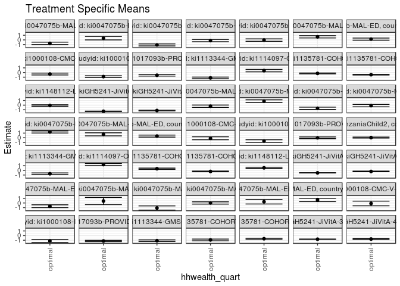

## Results Table

### Parameter: TSM

| agecat | studyid | country | intervention_level | baseline_level | estimate | ci_lower | ci_upper |
| --- | --- | --- | --- | --- | --- | --- | --- |
| Birth | ki0047075b-MAL-ED | BANGLADESH | optimal | observed | -0.6955886 | -0.9987856 | -0.3923915 |
| Birth | ki0047075b-MAL-ED | BRAZIL | optimal | observed | 0.4190501 | -0.3553623 | 1.1934625 |
| Birth | ki0047075b-MAL-ED | INDIA | optimal | observed | -1.0773123 | -1.5237229 | -0.6309017 |
| Birth | ki0047075b-MAL-ED | PERU | optimal | observed | 0.0041519 | -0.2389854 | 0.2472891 |
| Birth | ki0047075b-MAL-ED | SOUTH AFRICA | optimal | observed | 0.2667510 | -0.2160828 | 0.7495847 |
| Birth | ki0047075b-MAL-ED | TANZANIA, UNITED REPUBLIC OF | optimal | observed | 0.6574378 | 0.2926183 | 1.0222573 |
| Birth | ki1000108-CMC-V-BCS-2002 | INDIA | optimal | observed | -0.1087046 | -0.6163519 | 0.3989427 |
| Birth | ki1000108-IRC | INDIA | optimal | observed | -1.1596038 | -1.4567574 | -0.8624501 |
| Birth | ki1017093b-PROVIDE | BANGLADESH | optimal | observed | -1.1567565 | -1.2941176 | -1.0193954 |
| Birth | ki1113344-GMS-Nepal | NEPAL | optimal | observed | -1.0880756 | -1.2606343 | -0.9155168 |
| Birth | ki1135781-COHORTS | GUATEMALA | optimal | observed | -0.9334092 | -1.1225184 | -0.7442999 |
| Birth | ki1135781-COHORTS | PHILIPPINES | optimal | observed | -0.6714766 | -0.7672393 | -0.5757138 |
| Birth | kiGH5241-JiVitA-3 | BANGLADESH | optimal | observed | -0.7753892 | -0.8119961 | -0.7387823 |
| Birth | kiGH5241-JiVitA-4 | BANGLADESH | optimal | observed | -0.7404149 | -0.8442643 | -0.6365655 |
| 6 months | ki0047075b-MAL-ED | BANGLADESH | optimal | observed | -0.2388297 | -0.4959625 | 0.0183031 |
| 6 months | ki0047075b-MAL-ED | BRAZIL | optimal | observed | 0.8613065 | 0.5787575 | 1.1438555 |
| 6 months | ki0047075b-MAL-ED | INDIA | optimal | observed | -0.6787019 | -0.9304802 | -0.4269236 |
| 6 months | ki0047075b-MAL-ED | NEPAL | optimal | observed | -0.1070240 | -0.3651064 | 0.1510585 |
| 6 months | ki0047075b-MAL-ED | PERU | optimal | observed | 1.2432480 | 1.0218889 | 1.4646070 |
| 6 months | ki0047075b-MAL-ED | SOUTH AFRICA | optimal | observed | 0.7357620 | 0.4060815 | 1.0654425 |
| 6 months | ki0047075b-MAL-ED | TANZANIA, UNITED REPUBLIC OF | optimal | observed | 0.3608441 | 0.1432820 | 0.5784063 |
| 6 months | ki1000108-CMC-V-BCS-2002 | INDIA | optimal | observed | -0.1100722 | -0.4288931 | 0.2087486 |
| 6 months | ki1000108-IRC | INDIA | optimal | observed | -0.6969734 | -0.9658250 | -0.4281219 |
| 6 months | ki1017093b-PROVIDE | BANGLADESH | optimal | observed | -0.0081613 | -0.1962455 | 0.1799229 |
| 6 months | ki1066203-TanzaniaChild2 | TANZANIA, UNITED REPUBLIC OF | optimal | observed | 0.0373526 | -0.0715245 | 0.1462298 |
| 6 months | ki1113344-GMS-Nepal | NEPAL | optimal | observed | -0.7289281 | -0.9040077 | -0.5538485 |
| 6 months | ki1114097-CONTENT | PERU | optimal | observed | 1.2416366 | 1.0085333 | 1.4747398 |
| 6 months | ki1135781-COHORTS | GUATEMALA | optimal | observed | 0.3542856 | 0.2193542 | 0.4892170 |
| 6 months | ki1135781-COHORTS | PHILIPPINES | optimal | observed | -0.2319272 | -0.3099752 | -0.1538792 |
| 6 months | ki1148112-LCNI-5 | MALAWI | optimal | observed | 0.5428369 | 0.4120421 | 0.6736316 |
| 6 months | kiGH5241-JiVitA-3 | BANGLADESH | optimal | observed | -0.5347348 | -0.5694980 | -0.4999715 |
| 6 months | kiGH5241-JiVitA-4 | BANGLADESH | optimal | observed | -0.2337782 | -0.3052675 | -0.1622888 |
| 24 months | ki0047075b-MAL-ED | BANGLADESH | optimal | observed | -0.7423062 | -1.0065927 | -0.4780198 |
| 24 months | ki0047075b-MAL-ED | BRAZIL | optimal | observed | 0.3753927 | 0.0045220 | 0.7462634 |
| 24 months | ki0047075b-MAL-ED | INDIA | optimal | observed | -1.0752999 | -1.2890567 | -0.8615430 |
| 24 months | ki0047075b-MAL-ED | NEPAL | optimal | observed | -0.1419505 | -0.3896254 | 0.1057245 |
| 24 months | ki0047075b-MAL-ED | PERU | optimal | observed | -0.0377709 | -0.3003441 | 0.2248022 |
| 24 months | ki0047075b-MAL-ED | SOUTH AFRICA | optimal | observed | 0.6636777 | 0.4196527 | 0.9077026 |
| 24 months | ki0047075b-MAL-ED | TANZANIA, UNITED REPUBLIC OF | optimal | observed | 0.1663186 | -0.0607147 | 0.3933518 |
| 24 months | ki1000108-CMC-V-BCS-2002 | INDIA | optimal | observed | -0.3262398 | -0.5292791 | -0.1232005 |
| 24 months | ki1000108-IRC | INDIA | optimal | observed | -0.8810755 | -1.0618440 | -0.7003071 |
| 24 months | ki1017093b-PROVIDE | BANGLADESH | optimal | observed | -0.5893013 | -0.7682850 | -0.4103176 |
| 24 months | ki1113344-GMS-Nepal | NEPAL | optimal | observed | -1.1575298 | -1.3333428 | -0.9817169 |
| 24 months | ki1114097-CONTENT | PERU | optimal | observed | 0.4085159 | 0.1471095 | 0.6699223 |
| 24 months | ki1135781-COHORTS | GUATEMALA | optimal | observed | -0.1884456 | -0.2767123 | -0.1001789 |
| 24 months | ki1135781-COHORTS | PHILIPPINES | optimal | observed | -0.4701683 | -0.5366986 | -0.4036380 |
| 24 months | ki1148112-LCNI-5 | MALAWI | optimal | observed | -0.0741894 | -0.2309296 | 0.0825508 |
| 24 months | kiGH5241-JiVitA-3 | BANGLADESH | optimal | observed | -1.3211574 | -1.3652099 | -1.2771049 |
| 24 months | kiGH5241-JiVitA-4 | BANGLADESH | optimal | observed | -1.1585733 | -1.2267151 | -1.0904316 |

### Parameter: E(Y)

| agecat | studyid | country | intervention_level | baseline_level | estimate | ci_lower | ci_upper |
| --- | --- | --- | --- | --- | --- | --- | --- |
| Birth | ki0047075b-MAL-ED | BANGLADESH | observed | observed | -0.9728358 | -1.1217009 | -0.8239707 |
| Birth | ki0047075b-MAL-ED | BRAZIL | observed | observed | 0.4643860 | 0.1360519 | 0.7927200 |
| Birth | ki0047075b-MAL-ED | INDIA | observed | observed | -0.9441026 | -1.2397919 | -0.6484132 |
| Birth | ki0047075b-MAL-ED | PERU | observed | observed | -0.0468095 | -0.1738806 | 0.0802616 |
| Birth | ki0047075b-MAL-ED | SOUTH AFRICA | observed | observed | -0.1729474 | -0.4186222 | 0.0727275 |
| Birth | ki0047075b-MAL-ED | TANZANIA, UNITED REPUBLIC OF | observed | observed | 0.7637500 | 0.5676177 | 0.9598823 |
| Birth | ki1000108-CMC-V-BCS-2002 | INDIA | observed | observed | -0.4648256 | -0.7643210 | -0.1653302 |
| Birth | ki1000108-IRC | INDIA | observed | observed | -1.0105831 | -1.1973019 | -0.8238643 |
| Birth | ki1017093b-PROVIDE | BANGLADESH | observed | observed | -1.2984586 | -1.3752758 | -1.2216415 |
| Birth | ki1113344-GMS-Nepal | NEPAL | observed | observed | -1.1164431 | -1.2040134 | -1.0288728 |
| Birth | ki1135781-COHORTS | GUATEMALA | observed | observed | -1.0572840 | -1.1606089 | -0.9539590 |
| Birth | ki1135781-COHORTS | PHILIPPINES | observed | observed | -0.7422912 | -0.7886598 | -0.6959226 |
| Birth | kiGH5241-JiVitA-3 | BANGLADESH | observed | observed | -0.7777103 | -0.7967006 | -0.7587201 |
| Birth | kiGH5241-JiVitA-4 | BANGLADESH | observed | observed | -0.6882498 | -0.7406539 | -0.6358456 |
| 6 months | ki0047075b-MAL-ED | BANGLADESH | observed | observed | -0.1333333 | -0.2623761 | -0.0042906 |
| 6 months | ki0047075b-MAL-ED | BRAZIL | observed | observed | 0.9720774 | 0.8078144 | 1.1363403 |
| 6 months | ki0047075b-MAL-ED | INDIA | observed | observed | -0.7102872 | -0.8371659 | -0.5834085 |
| 6 months | ki0047075b-MAL-ED | NEPAL | observed | observed | 0.1104308 | -0.0208643 | 0.2417259 |
| 6 months | ki0047075b-MAL-ED | PERU | observed | observed | 1.0512099 | 0.9285617 | 1.1738581 |
| 6 months | ki0047075b-MAL-ED | SOUTH AFRICA | observed | observed | 0.5404351 | 0.3867005 | 0.6941696 |
| 6 months | ki0047075b-MAL-ED | TANZANIA, UNITED REPUBLIC OF | observed | observed | 0.5362213 | 0.4049390 | 0.6675036 |
| 6 months | ki1000108-CMC-V-BCS-2002 | INDIA | observed | observed | -0.5026766 | -0.6536848 | -0.3516685 |
| 6 months | ki1000108-IRC | INDIA | observed | observed | -0.5989297 | -0.7344491 | -0.4634104 |
| 6 months | ki1017093b-PROVIDE | BANGLADESH | observed | observed | -0.1990907 | -0.2817968 | -0.1163845 |
| 6 months | ki1066203-TanzaniaChild2 | TANZANIA, UNITED REPUBLIC OF | observed | observed | 0.0801680 | 0.0273223 | 0.1330136 |
| 6 months | ki1113344-GMS-Nepal | NEPAL | observed | observed | -0.6038416 | -0.6899448 | -0.5177384 |
| 6 months | ki1114097-CONTENT | PERU | observed | observed | 1.0684318 | 0.9515274 | 1.1853362 |
| 6 months | ki1135781-COHORTS | GUATEMALA | observed | observed | 0.1914471 | 0.1185005 | 0.2643936 |
| 6 months | ki1135781-COHORTS | PHILIPPINES | observed | observed | -0.2938433 | -0.3352064 | -0.2524802 |
| 6 months | ki1148112-LCNI-5 | MALAWI | observed | observed | 0.4417647 | 0.3702742 | 0.5132552 |
| 6 months | kiGH5241-JiVitA-3 | BANGLADESH | observed | observed | -0.5932502 | -0.6127743 | -0.5737261 |
| 6 months | kiGH5241-JiVitA-4 | BANGLADESH | observed | observed | -0.3901595 | -0.4274150 | -0.3529041 |
| 24 months | ki0047075b-MAL-ED | BANGLADESH | observed | observed | -0.8192925 | -0.9412667 | -0.6973182 |
| 24 months | ki0047075b-MAL-ED | BRAZIL | observed | observed | 0.4626233 | 0.2567495 | 0.6684971 |
| 24 months | ki0047075b-MAL-ED | INDIA | observed | observed | -0.9516520 | -1.0670654 | -0.8362385 |
| 24 months | ki0047075b-MAL-ED | NEPAL | observed | observed | -0.3749123 | -0.4886073 | -0.2612173 |
| 24 months | ki0047075b-MAL-ED | PERU | observed | observed | 0.1111982 | -0.0118399 | 0.2342362 |
| 24 months | ki0047075b-MAL-ED | SOUTH AFRICA | observed | observed | 0.4090301 | 0.2879441 | 0.5301161 |
| 24 months | ki0047075b-MAL-ED | TANZANIA, UNITED REPUBLIC OF | observed | observed | 0.0547975 | -0.0703378 | 0.1799328 |
| 24 months | ki1000108-CMC-V-BCS-2002 | INDIA | observed | observed | -0.5571505 | -0.6585247 | -0.4557763 |
| 24 months | ki1000108-IRC | INDIA | observed | observed | -0.7458150 | -0.8368180 | -0.6548120 |
| 24 months | ki1017093b-PROVIDE | BANGLADESH | observed | observed | -0.8928670 | -0.9755153 | -0.8102187 |
| 24 months | ki1113344-GMS-Nepal | NEPAL | observed | observed | -1.1363107 | -1.2252817 | -1.0473398 |
| 24 months | ki1114097-CONTENT | PERU | observed | observed | 0.5668293 | 0.4302437 | 0.7034148 |
| 24 months | ki1135781-COHORTS | GUATEMALA | observed | observed | -0.2791396 | -0.3336899 | -0.2245893 |
| 24 months | ki1135781-COHORTS | PHILIPPINES | observed | observed | -0.6099592 | -0.6467541 | -0.5731643 |
| 24 months | ki1148112-LCNI-5 | MALAWI | observed | observed | -0.0477867 | -0.1301103 | 0.0345368 |
| 24 months | kiGH5241-JiVitA-3 | BANGLADESH | observed | observed | -1.2973086 | -1.3206115 | -1.2740057 |
| 24 months | kiGH5241-JiVitA-4 | BANGLADESH | observed | observed | -1.2231776 | -1.2550332 | -1.1913220 |

### Parameter: PAR

| agecat | studyid | country | intervention_level | baseline_level | estimate | ci_lower | ci_upper |
| --- | --- | --- | --- | --- | --- | --- | --- |
| Birth | ki0047075b-MAL-ED | BANGLADESH | optimal | observed | -0.2772473 | -0.5422189 | -0.0122756 |
| Birth | ki0047075b-MAL-ED | BRAZIL | optimal | observed | 0.0453358 | -0.6416111 | 0.7322828 |
| Birth | ki0047075b-MAL-ED | INDIA | optimal | observed | 0.1332097 | -0.2994847 | 0.5659042 |
| Birth | ki0047075b-MAL-ED | PERU | optimal | observed | -0.0509614 | -0.2684303 | 0.1665075 |
| Birth | ki0047075b-MAL-ED | SOUTH AFRICA | optimal | observed | -0.4396983 | -0.9032910 | 0.0238944 |
| Birth | ki0047075b-MAL-ED | TANZANIA, UNITED REPUBLIC OF | optimal | observed | 0.1063122 | -0.2077878 | 0.4204123 |
| Birth | ki1000108-CMC-V-BCS-2002 | INDIA | optimal | observed | -0.3561210 | -0.8211474 | 0.1089055 |
| Birth | ki1000108-IRC | INDIA | optimal | observed | 0.1490207 | -0.0977809 | 0.3958222 |
| Birth | ki1017093b-PROVIDE | BANGLADESH | optimal | observed | -0.1417022 | -0.2579430 | -0.0254614 |
| Birth | ki1113344-GMS-Nepal | NEPAL | optimal | observed | -0.0283675 | -0.1696553 | 0.1129204 |
| Birth | ki1135781-COHORTS | GUATEMALA | optimal | observed | -0.1238748 | -0.2841462 | 0.0363966 |
| Birth | ki1135781-COHORTS | PHILIPPINES | optimal | observed | -0.0708147 | -0.1540785 | 0.0124492 |
| Birth | kiGH5241-JiVitA-3 | BANGLADESH | optimal | observed | -0.0023212 | -0.0344689 | 0.0298266 |
| Birth | kiGH5241-JiVitA-4 | BANGLADESH | optimal | observed | 0.0521651 | -0.0340949 | 0.1384251 |
| 6 months | ki0047075b-MAL-ED | BANGLADESH | optimal | observed | 0.1054964 | -0.1155725 | 0.3265653 |
| 6 months | ki0047075b-MAL-ED | BRAZIL | optimal | observed | 0.1107708 | -0.1508770 | 0.3724186 |
| 6 months | ki0047075b-MAL-ED | INDIA | optimal | observed | -0.0315853 | -0.2522112 | 0.1890405 |
| 6 months | ki0047075b-MAL-ED | NEPAL | optimal | observed | 0.2174548 | -0.0078910 | 0.4428005 |
| 6 months | ki0047075b-MAL-ED | PERU | optimal | observed | -0.1920381 | -0.3926415 | 0.0085653 |
| 6 months | ki0047075b-MAL-ED | SOUTH AFRICA | optimal | observed | -0.1953269 | -0.4802982 | 0.0896444 |
| 6 months | ki0047075b-MAL-ED | TANZANIA, UNITED REPUBLIC OF | optimal | observed | 0.1753772 | -0.0286316 | 0.3793860 |
| 6 months | ki1000108-CMC-V-BCS-2002 | INDIA | optimal | observed | -0.3926044 | -0.6623761 | -0.1228326 |
| 6 months | ki1000108-IRC | INDIA | optimal | observed | 0.0980437 | -0.1352684 | 0.3313558 |
| 6 months | ki1017093b-PROVIDE | BANGLADESH | optimal | observed | -0.1909294 | -0.3444361 | -0.0374227 |
| 6 months | ki1066203-TanzaniaChild2 | TANZANIA, UNITED REPUBLIC OF | optimal | observed | 0.0428153 | -0.0528067 | 0.1384374 |
| 6 months | ki1113344-GMS-Nepal | NEPAL | optimal | observed | 0.1250865 | -0.0278603 | 0.2780333 |
| 6 months | ki1114097-CONTENT | PERU | optimal | observed | -0.1732048 | -0.3789504 | 0.0325409 |
| 6 months | ki1135781-COHORTS | GUATEMALA | optimal | observed | -0.1628385 | -0.2761494 | -0.0495276 |
| 6 months | ki1135781-COHORTS | PHILIPPINES | optimal | observed | -0.0619161 | -0.1304133 | 0.0065811 |
| 6 months | ki1148112-LCNI-5 | MALAWI | optimal | observed | -0.1010721 | -0.2174505 | 0.0153062 |
| 6 months | kiGH5241-JiVitA-3 | BANGLADESH | optimal | observed | -0.0585154 | -0.0882625 | -0.0287683 |
| 6 months | kiGH5241-JiVitA-4 | BANGLADESH | optimal | observed | -0.1563814 | -0.2171676 | -0.0955951 |
| 24 months | ki0047075b-MAL-ED | BANGLADESH | optimal | observed | -0.0769862 | -0.3324212 | 0.1784488 |
| 24 months | ki0047075b-MAL-ED | BRAZIL | optimal | observed | 0.0872306 | -0.2464710 | 0.4209321 |
| 24 months | ki0047075b-MAL-ED | INDIA | optimal | observed | 0.1236479 | -0.0672731 | 0.3145688 |
| 24 months | ki0047075b-MAL-ED | NEPAL | optimal | observed | -0.2329618 | -0.4403846 | -0.0255390 |
| 24 months | ki0047075b-MAL-ED | PERU | optimal | observed | 0.1489691 | -0.0882356 | 0.3861738 |
| 24 months | ki0047075b-MAL-ED | SOUTH AFRICA | optimal | observed | -0.2546475 | -0.4651940 | -0.0441010 |
| 24 months | ki0047075b-MAL-ED | TANZANIA, UNITED REPUBLIC OF | optimal | observed | -0.1115210 | -0.3090892 | 0.0860471 |
| 24 months | ki1000108-CMC-V-BCS-2002 | INDIA | optimal | observed | -0.2309107 | -0.4051308 | -0.0566907 |
| 24 months | ki1000108-IRC | INDIA | optimal | observed | 0.1352605 | -0.0227103 | 0.2932313 |
| 24 months | ki1017093b-PROVIDE | BANGLADESH | optimal | observed | -0.3035657 | -0.4491575 | -0.1579739 |
| 24 months | ki1113344-GMS-Nepal | NEPAL | optimal | observed | 0.0212191 | -0.1356100 | 0.1780482 |
| 24 months | ki1114097-CONTENT | PERU | optimal | observed | 0.1583133 | -0.0743709 | 0.3909976 |
| 24 months | ki1135781-COHORTS | GUATEMALA | optimal | observed | -0.0906939 | -0.1588627 | -0.0225252 |
| 24 months | ki1135781-COHORTS | PHILIPPINES | optimal | observed | -0.1397909 | -0.1964112 | -0.0831705 |
| 24 months | ki1148112-LCNI-5 | MALAWI | optimal | observed | 0.0264027 | -0.1086489 | 0.1614542 |
| 24 months | kiGH5241-JiVitA-3 | BANGLADESH | optimal | observed | 0.0238488 | -0.0143862 | 0.0620839 |
| 24 months | kiGH5241-JiVitA-4 | BANGLADESH | optimal | observed | -0.0646042 | -0.1220119 | -0.0071966 |